# Analyzing Daphnia Growth and Parasitism: Uncovering Relationships with one way ANOVA

Pascal Bärtschi

2023-08-10

This code explores the relationship between Daphnia growth and parasitism using data analysis techniques. Daphnia, tiny aquatic organisms, are indicators of ecosystem health. We delve into a dataset called “Daphniagrowth.csv” to investigate potential associations between growth rate and the presence of parasites.

#### Prerequisites and data loading

#### Data Exploration

We begin by loading the data set and gaining initial insights using `glimpse()` and `summary()`. We also create a distribution of parasite occurrences with the `table()` function.

```r
glimpse(data)
```

```
## Rows: 40
## Columns: 3
## $ parasite    <fct> control, control, control, control, control, control, control, contro~
## $ rep         <int> 1, 2, 3, 4, 5, 6, 7, 8, 9, 10, 1, 2, 3, 4, 5, 6, 7, 8, 9, 10, 1, 2, 3~
## $ growth.rate <dbl> 1.0747092, 1.2659016, 1.3151563, 1.0757519, 1.1967619, 1.3837955, 1.3~
```

```r
summary(data)
```

```
##                       parasite       rep        growth.rate
##  control                  :10   Min.   : 1.0   Min.   :0.1246
##  Metschnikowia bicuspidata:10   1st Qu.: 3.0   1st Qu.:0.6490
##  Pansporella perplexa     :10   Median : 5.5   Median :0.9502
##  Pasteuria ramosa         :10   Mean   : 5.5   Mean   :0.8934
##                                 3rd Qu.: 8.0   3rd Qu.:1.1250
##                                 Max.   :10.0   Max.   :1.3838
```

```r
table(data$parasite)
```

```
##
##                   control Metschnikowia bicuspidata      Pansporella perplexa
##                        10                        10                        10
##          Pasteuria ramosa
##                        10
```

#### Visual Insight

Visualizations play a vital role. We use ggplot2 to create a box and whisker plot, showing growth rate distribution across parasite groups. Flipping the axes clarifies the view.

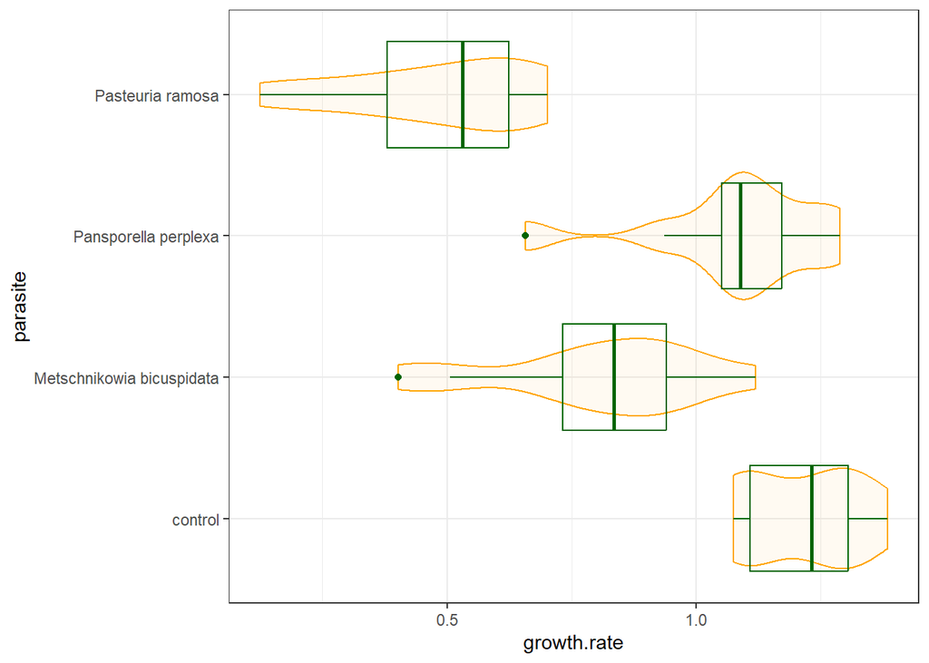

```r
ggplot(data, aes(x = parasite, y = growth.rate)) +
  geom_violin(fill = "orange", color = "orange",  alpha = 0.05) +
  geom_boxplot(fill = NA, color = "darkgreen") +
  theme_bw() +
  coord_flip() # flips axes to see full parasite names
```

#### Modeling the Connection

Linear regression is employed to model growth rates based on parasitism. The model, named model_grow, estimates growth variations among parasite groups.

```r
model_grow = lm(growth.rate ~ parasite, data = data)
```

#### Model Visualization

The `autoplot()` function serves to check skewedness of the data or correlations between fitted values and residuals.

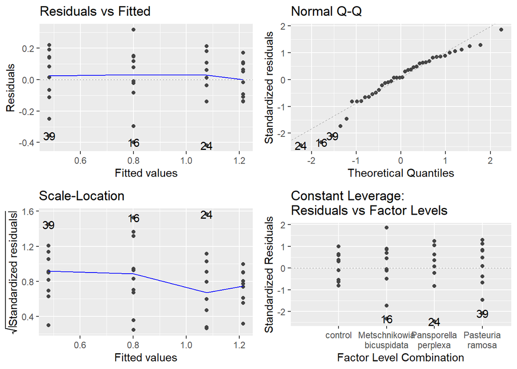

```r
autoplot(model_grow, smooth.color = NA)
```

The data is a bit skewed (Q-Q) but seem ok, however we need to note that the standardized residuals show tiny correlation (Scale-Location) with the fit.

#### Statistical Analysis

We perform ANOVA using `anova()` to assess if parasite groups lead to distinct growth rates. The F-value informs us about between-group versus within-group variance.

```r
anova(model_grow)
```

```
## Analysis of Variance Table
##
## Response: growth.rate
##           Df Sum Sq Mean Sq F value    Pr(>F)
## parasite   3 3.1379 1.04597  32.325 2.571e-10 ***
## Residuals 36 1.1649 0.03236
## ---
## Signif. codes:  0 '***' 0.001 '**' 0.01 '*' 0.05 '.' 0.1 ' ' 1
```

```r
# H0: all groups come from populations with the same mean
# F-value: ratio of in between group variance to the within group variance
```

- The “parasite” factor has 3 degrees of freedom and a sum of squares of 3.1379. The mean sum of squares is 1.04597, resulting in a relatively high F value of 32.325.
- The associated p-value (Pr(>F)) is very close to zero (2.571e-10), which is much smaller than the typical significance level of 0.05. This suggests that the effect of the “parasite” factor on the “growth.rate” is statistically significant.

```r
summary(model_grow)
```

```
##
## Call:
## lm(formula = growth.rate ~ parasite, data = data)
##
## Residuals:
##      Min       1Q   Median       3Q      Max
## -0.41930 -0.09696  0.01408  0.12267  0.31790
##
## Coefficients:
##                                   Estimate Std. Error t value Pr(>|t|)
## (Intercept)                        1.21391    0.05688  21.340  < 2e-16 ***
## parasiteMetschnikowia bicuspidata -0.41275    0.08045  -5.131 1.01e-05 ***
## parasitePansporella perplexa      -0.13755    0.08045  -1.710   0.0959 .
## parasitePasteuria ramosa          -0.73171    0.08045  -9.096 7.34e-11 ***
## ---
## Signif. codes:  0 '***' 0.001 '**' 0.01 '*' 0.05 '.' 0.1 ' ' 1
##
## Residual standard error: 0.1799 on 36 degrees of freedom
## Multiple R-squared:  0.7293, Adjusted R-squared:  0.7067
## F-statistic: 32.33 on 3 and 36 DF,  p-value: 2.571e-10
```

#### Group Comparisons

Using `summarise()`, we compute mean growth rates for each parasite group. The results are visualized alongside individual data points, offering a comprehensive growth rate trend overview.

```r
sumDat <- data %>%
  group_by(parasite) %>%
  summarise(meanGR = mean(growth.rate))

sumDat
```

```
## # A tibble: 4 x 2
##   parasite                  meanGR
##   <fct>                      <dbl>
## 1 control                    1.21
## 2 Metschnikowia bicuspidata  0.801
## 3 Pansporella perplexa       1.08
## 4 Pasteuria ramosa           0.482
```

#### ANOVA visualization: grouped means of growth by parasite

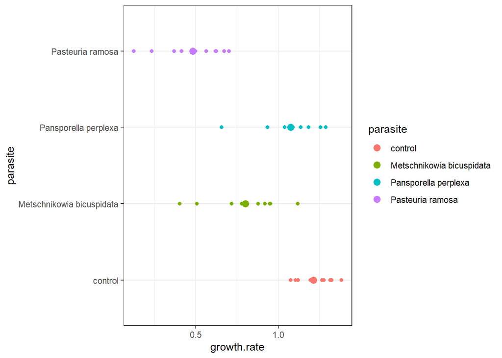

```r
ggplot() +
  geom_point(data = data, mapping = aes(x= parasite, y = growth.rate, color = parasite)) +
  geom_point(data = sumDat, mapping = aes(x = parasite, y = meanGR, color = parasite), size= 3) +
  theme_bw() +
  coord_flip()
```

#### Conclusion

This ANOVA analysis unravels that there is a relationship between parasite and growth rate of daphnia, indicated by the relatively high F-value and the p-value close to zero.